# Logistic Regression - Predicting Diabetes Diagnosis

05/18/2020

Victor Uduma

## Data Cleaning/Preparation

```r
setwd('/Users/victoruduma/ice4') #set working directory
getwd()
library(dplyr)
library(Hmisc)
library(ggplot2)
library(summarytools)

diabetes_df = read.csv('diabetes.csv')# read data in
diabetes_df$height.si = diabetes_df$height * 0.0254 #converting height
diabetes_df$weight.si = diabetes_df$weight *  0.453592 #converting weight
diabetes_df$BMI = diabetes_df$weight.si/diabetes_df$height.si^2

#recoded BMI categories
diabetes_df$bmi_categorized = ifelse(diabetes_df$BMI < 18.5, 'underweight',
                         ifelse(diabetes_df$BMI >= 18.5 & diabetes_df$BMI <= 25, 'normal',
                                ifelse(diabetes_df$BMI > 25 & diabetes_df$BMI <= 30, 'overweight',
                                       ifelse(diabetes_df$BMI > 30, 'Obese',
                                              NA))))




#recode insurance values
diabetes_df <- mutate(diabetes_df, insurance = ifelse(insurance == 1, 'government', insurance))
diabetes_df <- mutate(diabetes_df, insurance = ifelse(insurance == 2, 'private', insurance))
diabetes_df <- mutate(diabetes_df, insurance = ifelse(insurance == 0, 'none', insurance))

#recode smoking values
diabetes_df <- mutate(diabetes_df, smoking = ifelse(smoking == 1, 'current', smoking))
diabetes_df <- mutate(diabetes_df, smoking = ifelse(smoking == 2, 'never', smoking))
diabetes_df <- mutate(diabetes_df, smoking = ifelse(smoking == 3, 'ex-smoker', smoking))
```

## Exploratory Data Analysis

in the dataset, there are 403 observations, with 28.46 percent of the observations being normal, 38.29 percent of observations being obese, 30.98 percent being overweight and 2.27 percent being underweight. in the observations, 58.06 percent are females while 41.94 percent are males. Only 15.38 have diabetes in the observations while 84.62 percent did not have diabetes. the average age rounded to be 47 and the average BMI was rounded to be 29.

```r
# find observations
nrow(diabetes_df)

# find percentages
freq(diabetes_df$bmi_categorized)

# percentage of each gender
freq(diabetes_df$gender)

#percentage diabetes
freq(diabetes_df$dm)
#average age
mean(diabetes_df$age)

#average bmi
mean(diabetes_df$BMI,na.rm = T)
```

[output not shown]

## Data Visualization

for figure 1, we decided to create a barchart to show the number people who enrolled in each type of insurance, we saw that people enrolled in governemnt insurance the most, with private being the second most common, and people not having insurance at all being the least common.

For figure 2 we made a Barchart to show the amount of people who smoked in the dataset, it showed that a majority of people didn’t smoke while ex smokers were the least.

For Figure 3 we made a scatter plot to see if there is a correlation between BMI and Cholesterol, we were able to determine that there is little correlation between BMI and Cholesterol and that they share no relationship with each other

for Figure 4 we made a historgram to see the age distribution, we could determine that the values are slighlty skewed to the right of the graph as there are some people in the dataset who are the age of 75 or older.

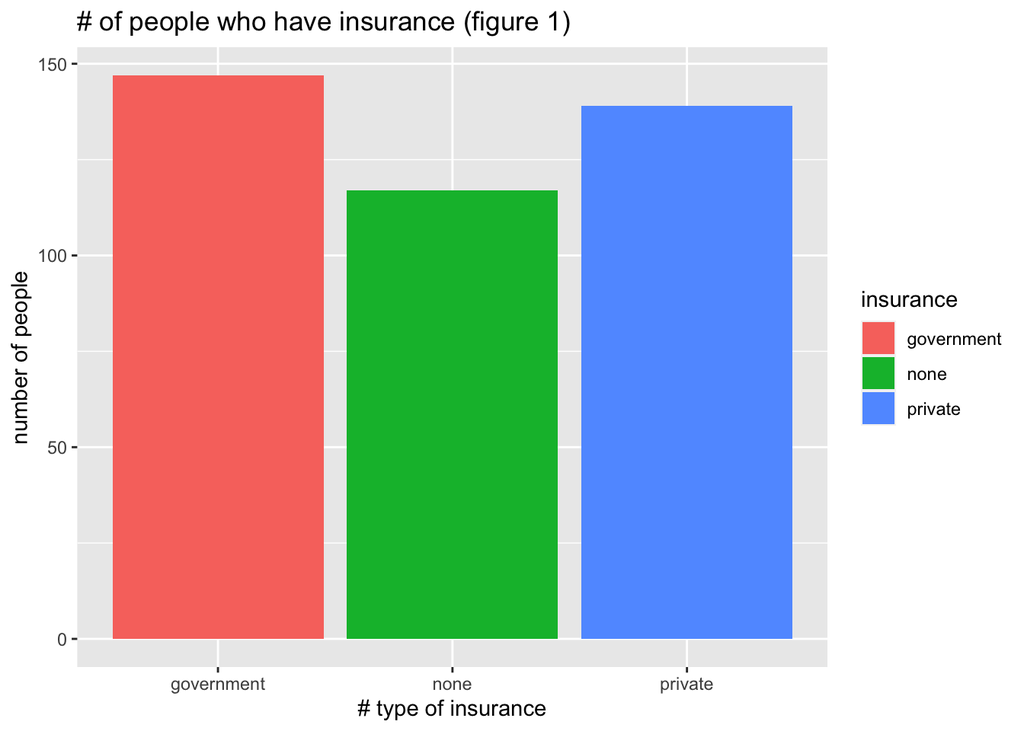

```r
#create barchart for insurance
ggplot(data = diabetes_df) +
  geom_bar(mapping = aes(x = insurance, fill = insurance))+
  labs(title = "# of people who have insurance (figure 1)", x ="# type of insurance", y = "number of people")
```

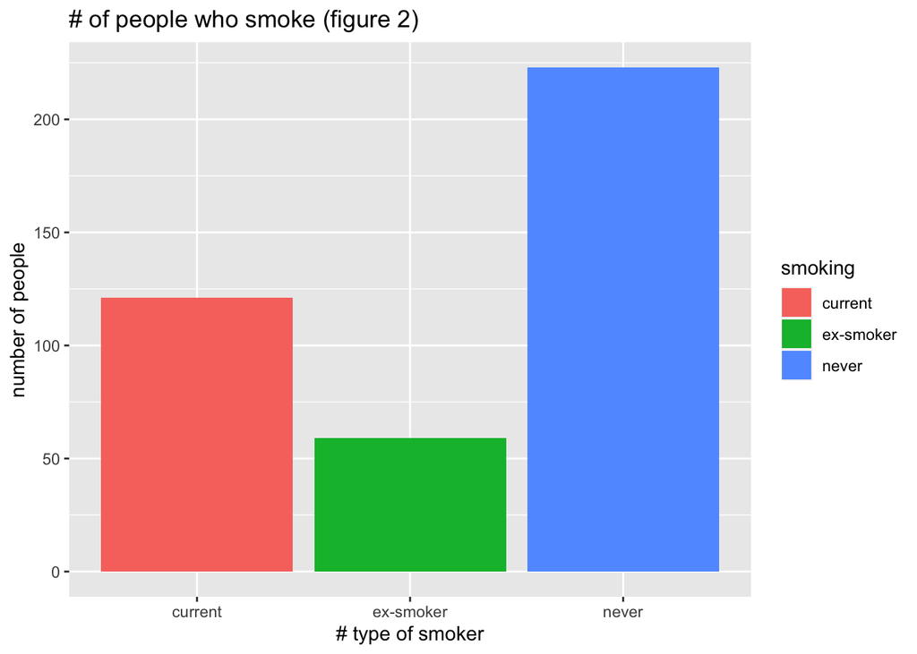

```r
#create barchart for smoking
ggplot(data = diabetes_df) +
  geom_bar(mapping = aes(x = smoking, fill = smoking))+
  labs(title = "# of people who smoke (figure 2)", x ="# type of smoker", y = "number of people")
```

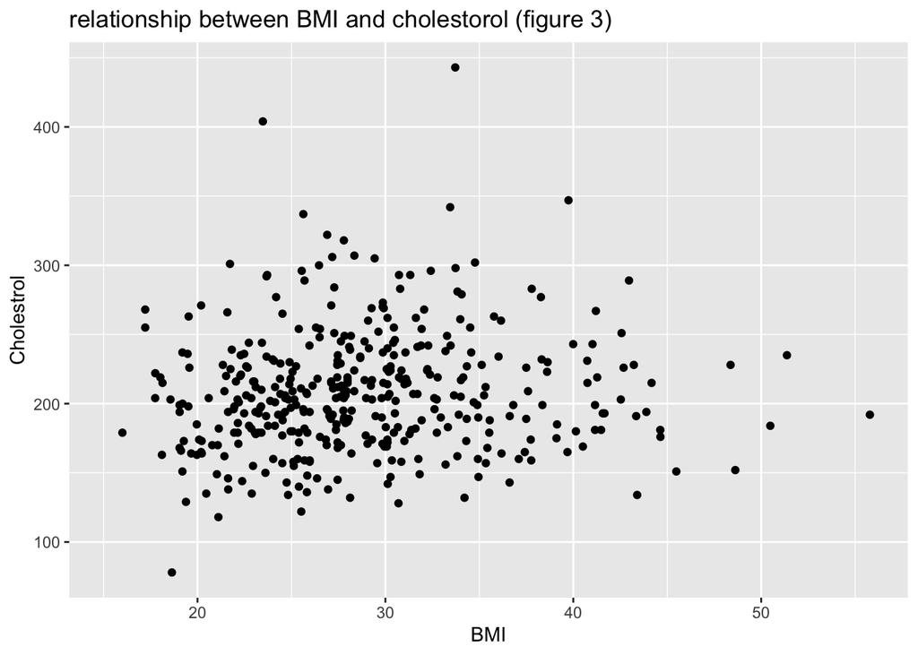

```r
#create scatterplot for relationship between BMI and cholestrol
ggplot(data= diabetes_df) +
  geom_point(mapping = aes(x=BMI, y=chol))+
  labs(title = "relationship between BMI and cholestorol (figure 3)", x = "BMI", y = "Cholestrol")
```

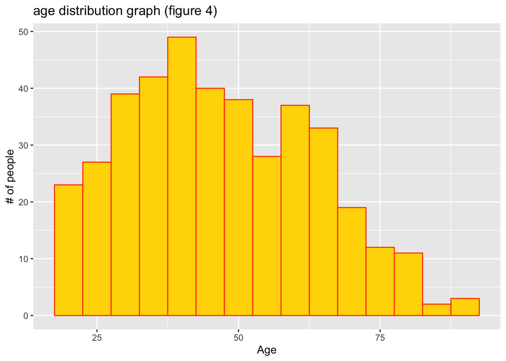

```r
#create historgram for age
ggplot(data= diabetes_df) +
  geom_histogram(mapping = aes(x=age), fill="gold", color="orangered", binwidth = 5)+
  labs(title = "age distribution graph (figure 4)", x = "Age", y = "# of people")
```

## Logistic Regression Results

lastly we were able to perform a logistic regression model to determine whether or not BMI,age and gender have an effect on you getting diabetes.

for the BMI, I was able to determine that a 1 unit increase in BMI causes the log odds of getting diabetes to increase by 0.073, holding all other independent variables constant

for Age, I was able to determine that a 1 year increase in age causes the log odds of getting diabetes to increase by 0.055, holding all other independent variables constant

for gender, I determined the log odds of getting diabetes between someone who is male and someone who is female is 0.24, holding all other independent variables constant.

```r
#create a logotc regression model to determine wheter age,gender or BMI have an effect on diabetes

fit1 = glm(dm ~ age + factor(gender) + BMI, data = diabetes_df, family = "binomial")
summary(fit1)
```

[output not shown]